# Marketing Mix Modeling R

Andrés Mahía Morado

21/10/2021

```r
library(janitor)
library(dplyr)
```

```r
library(ggplot2)
library(tidyr)
library(purrr)
```

We use relative adresses in order to retrieve the data. In this case, Working directory is set to the same folder the script is being ran from, where mktmix.csv is also located.

```r
setwd(dirname(rstudioapi::getActiveDocumentContext()$path))
```

### 1

```r
df_mmm <- clean_names(read.csv("mktmix.csv"))
```

### 2

```r
ncol(df_mmm)
```

```
## [1] 9
```

```r
nrow(df_mmm)
```

```
## [1] 104
```

```r
class(df_mmm$base_price)
```

```
## [1] "numeric"
```

```r
class(df_mmm$discount)
```

```
## [1] "numeric"
```

Both base_price and discount are numeric columns. We can assume base_price is the price of a certain product before applying any discounts. Knowing that discount is always between 0 and 1 after having a look at the data-frame, we can assume its the percentage of discount applied to a certain product or sale. ### 3

```r
df_mmm$newspaper_inserts <-
  as.numeric(as.factor(df_mmm$newspaper_inserts)) - 1
class(df_mmm$newspaper_inserts)
```

```
## [1] "numeric"
```

```r
df_mmm$newspaper_inserts
```

```
##   [1] 0 0 0 0 0 0 0 0 0 0 0 0 0 0 0 0 0 0 1 0 0 0 0 0 0 0 0 0 0 0 0 0 0 0 0 0 0
##  [38] 0 1 0 0 0 0 0 1 0 0 0 0 0 0 0 0 1 0 0 0 0 0 0 0 0 0 0 0 1 0 0 0 0 0 0 0 0
##  [75] 0 0 0 0 0 0 0 0 0 0 0 0 0 0 0 0 0 0 0 0 0 0 0 1 0 0 0 0 0 0
```

### 4

```r
unique(as.factor(df_mmm$website_campaign))
```

```
## [1]                   Facebook          Twitter           Website Campaign
## Levels:  Facebook Twitter Website Campaign
```

```r
length(unique(as.factor(df_mmm$website_campaign))) - 1
```

```
## [1] 3
```

### 5

For some reason the “Website Campaign” values were input incorrectly in the data frame, leaving a space after Campaign as in “Website Campaign” We are modifying that too to prevent future mistakes.

```r
df_mmm %>%
  select(website_campaign) %>%
  mutate(website_campaign = replace(website_campaign, website_campaign=="Website Campaign ", "Website Campaign"),
         Facebook = as.numeric(website_campaign == "Facebook"),
         Twitter = as.numeric(website_campaign == "Twitter"),
         WebsiteCampaign = as.numeric(website_campaign == "Website Campaign"))
```

```
##     website_campaign Facebook Twitter WebsiteCampaign
## 1                           0       0               0
## 2                           0       0               0
## 3                           0       0               0
## 4                           0       0               0
## 5                           0       0               0
## 6                           0       0               0
## 7                           0       0               0
## 8                           0       0               0
## 9                           0       0               0
## 10                          0       0               0
## 11                          0       0               0
## 12          Facebook        1       0               0
## 13          Facebook        1       0               0
## 14          Facebook        1       0               0
```

[output cut: 90 more lines]

### 6

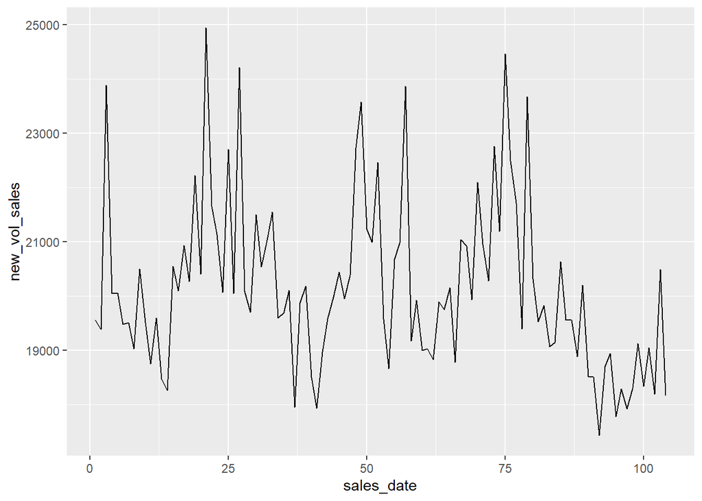

```r
sales_date <- c(1:length(df_mmm$new_vol_sales))
ggplot(df_mmm) +
  geom_line(aes(y = new_vol_sales, x = sales_date))
```

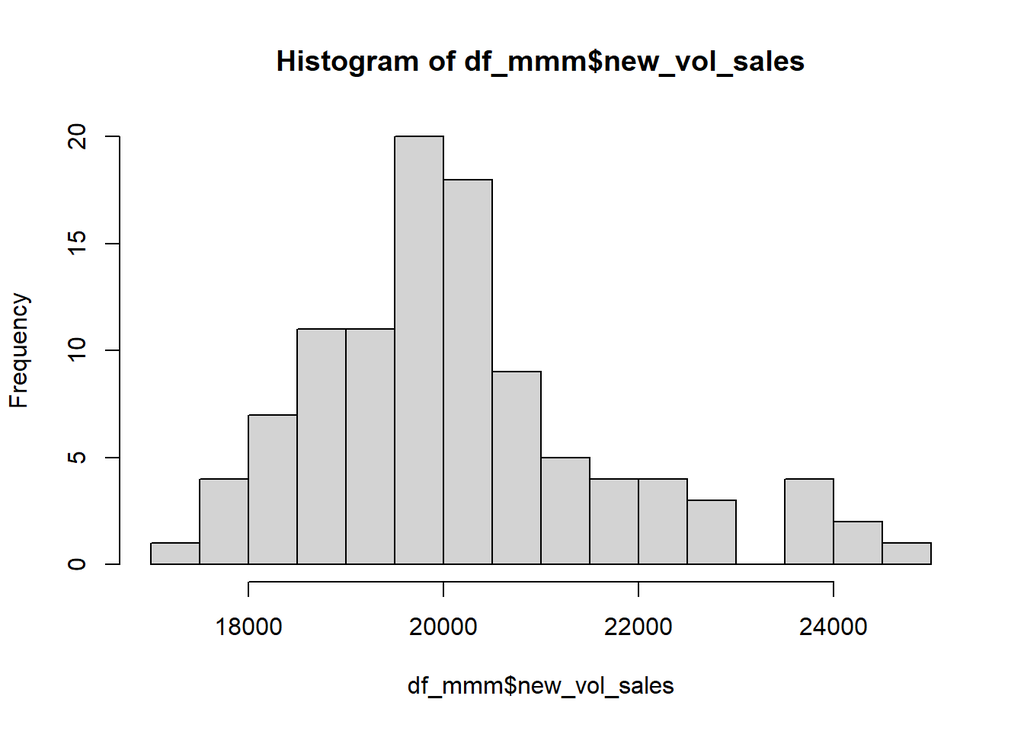

```r
hist(df_mmm$new_vol_sales, breaks = 20)
```

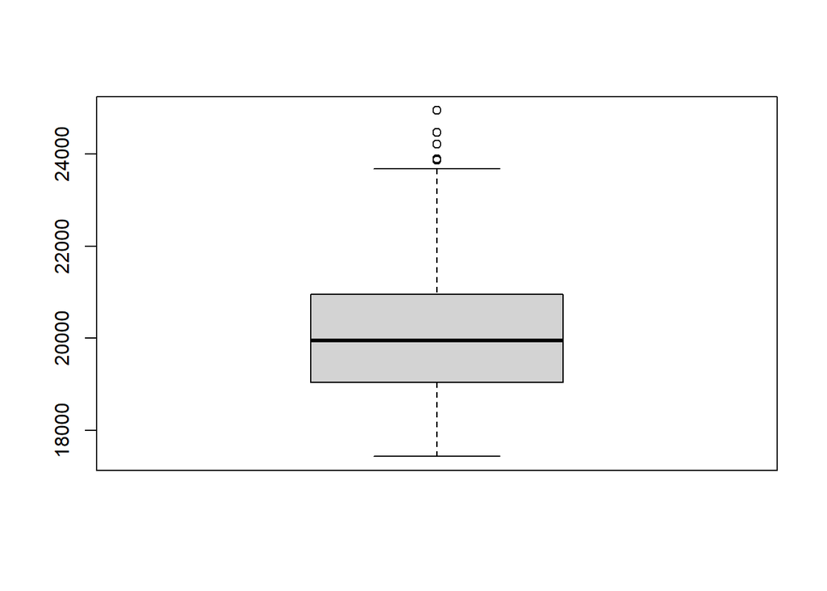

```r
boxplot(df_mmm$new_vol_sales)
```

Based mainly on the results obtained via boxplot, we can assume the median for new_vol_sales will be somewhere around 20000.

```r
median(df_mmm$new_vol_sales)
```

```
## [1] 19943.5
```

### 7

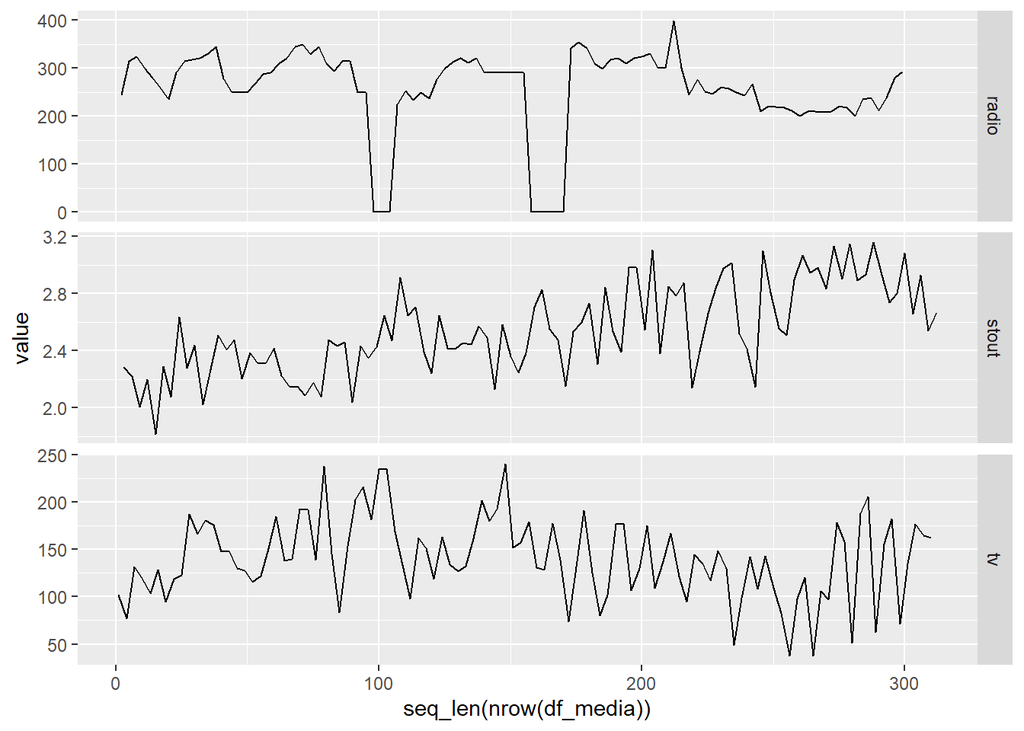

```r
df_media <- df_mmm %>%
  select(tv, radio, stout)%>%
  pivot_longer(everything())

df_media %>%
  ggplot(aes(x=seq_len(nrow(df_media)), y=value))+
  geom_line()+
  facet_grid(name~., scales="free")
```

In the plot(s) we can observe how the stout and tv columns apparently have relatively similar variance (without making any calculations on it) and the radio column has higher variability, mainly based on the rows in which its value is 0.

### 8

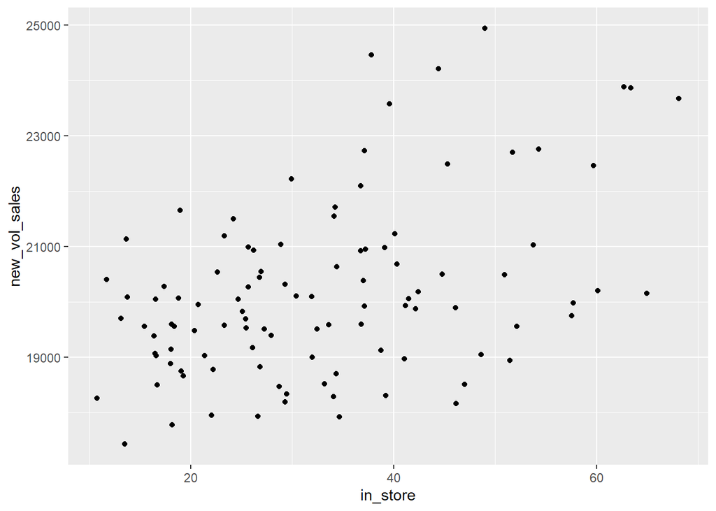

```r
df_mmm %>%
  ggplot(aes(x=in_store, y=new_vol_sales)) +
  geom_point()
```

```r
# function for variable-based point color

scatter_color <- function(j){
  df_mmm %>%
    ggplot(aes(x=in_store, y=new_vol_sales, color=j)) +
    geom_point()
}
```

I have chosen new_vol_sales to be on the y axis because it is much easier to visualize its evolution this way. We should always place the dependent variable on the y axis if we want to explain it through other variables (such as in_store in this case) We can observe certain positive correlation between in_store and new_vol_sales, where the higher in_store is the higher new_vol_sales will be or the other way around.

### 9

#### Based on newspaper_inserts:

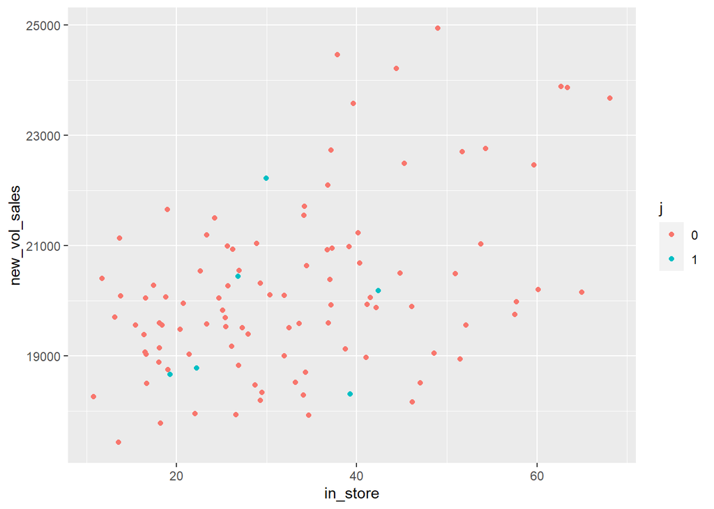

```r
scatter_color(as.factor(df_mmm$newspaper_inserts))
```

#### Based on the tv column:

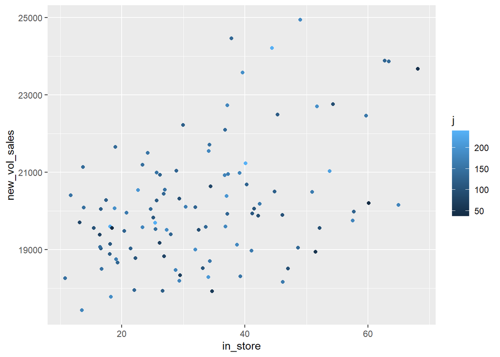

```r
scatter_color(df_mmm$tv)
```

### 10

```r
df_mmm <- df_mmm %>%
  group_by(
    discount_yesno = ifelse(discount==0, FALSE, TRUE))

df_mmm_mean <- df_mmm %>%
  select(base_price, discount_yesno) %>%
  group_by(discount_yesno) %>%
  summarize(average_price = mean(base_price)) %>%
  ggplot(aes(x=discount_yesno,
             y=average_price,
             fill=discount_yesno)) +
  geom_col() +
  coord_cartesian(ylim=c(14.5,15.5))

df_mmm_mean$data
```

```
## # A tibble: 2 x 2
##   discount_yesno average_price
##   <lgl>                  <dbl>
## 1 FALSE                   15.4
## 2 TRUE                    15.2
```

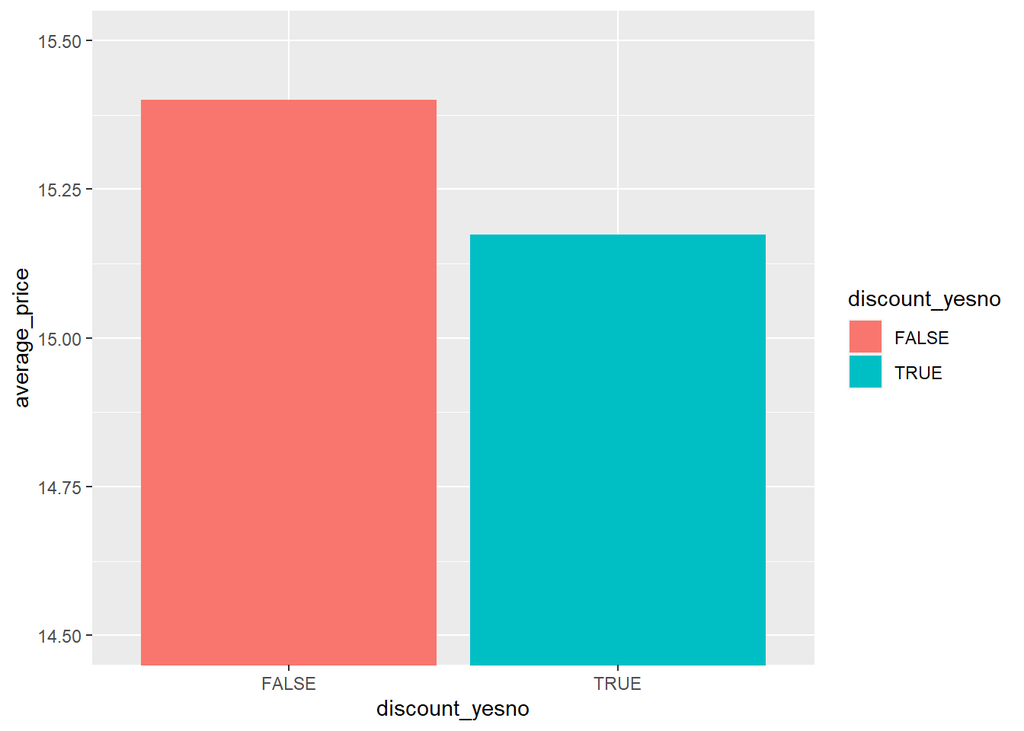

```r
df_mmm_mean
```

### 11

```r
regresion_columns <- function(columns){
  df_aux <- df_mmm %>%
    select(new_vol_sales,columns)
  my_model <- lm(new_vol_sales ~ ., data = df_aux)
  return(summary(my_model)$adj.r.squared)
}

regresion_columns(c("base_price","tv"))
```

```
## Note: Using an external vector in selections is ambiguous.
## i Use `all_of(columns)` instead of `columns` to silence this message.
## i See <https://tidyselect.r-lib.org/reference/faq-external-vector.html>.
```

```
## [1] 0.61748
```

### 12

```r
l1 <- c("base_price", "radio", "tv", "stout")
l2 <- c("base_price", "in_store", "discount", "radio", "tv", "stout")
l3 <- c("in_store", "discount")
lista_regresion <- list(l1, l2, l3)
lista_regresion[[2]]
```

```
## [1] "base_price" "in_store"   "discount"   "radio"      "tv"
## [6] "stout"
```

```r
map <- map(lista_regresion, regresion_columns)
for (j in 1:3){
  print(c("The variables used for the model are:",
          lista_regresion[[j]],
          "And the R-Squared for the model is:"))
  print(map[[j]])
}
```

```
## [1] "The variables used for the model are:"
## [2] "base_price"
## [3] "radio"
## [4] "tv"
## [5] "stout"
## [6] "And the R-Squared for the model is:"
## [1] 0.7480164
## [1] "The variables used for the model are:"
## [2] "base_price"
## [3] "in_store"
## [4] "discount"
## [5] "radio"
## [6] "tv"
## [7] "stout"
## [8] "And the R-Squared for the model is:"
## [1] 0.7815387
## [1] "The variables used for the model are:"
## [2] "in_store"
## [3] "discount"
## [4] "And the R-Squared for the model is:"
## [1] 0.2039676
```

### Simple calculation of the maximum rsquared value

```r
m <- unlist(map)
mmax <- max(m)
mmaxn <- which.max(m)
mmaxlista <- lista_regresion[[which.max(m)]]

print(c("Maximum R-squared value found was:",
        mmax,
        "Variables used to estimate the regression were:",
        mmaxlista))
```

```
## [1] "Maximum R-squared value found was:"
## [2] "0.781538729459471"
## [3] "Variables used to estimate the regression were:"
## [4] "base_price"
## [5] "in_store"
## [6] "discount"
## [7] "radio"
## [8] "tv"
## [9] "stout"
```